# R Notebook

This is my first notebook. It will have some text and an example of code.

I am currently learning from [Geocomputation in R](https://r.geocompx.org/). I can copy some exercises from there.

But I will begin with a simple chunk of code that uses the built-in cars dataset.

This is a plot in base R:

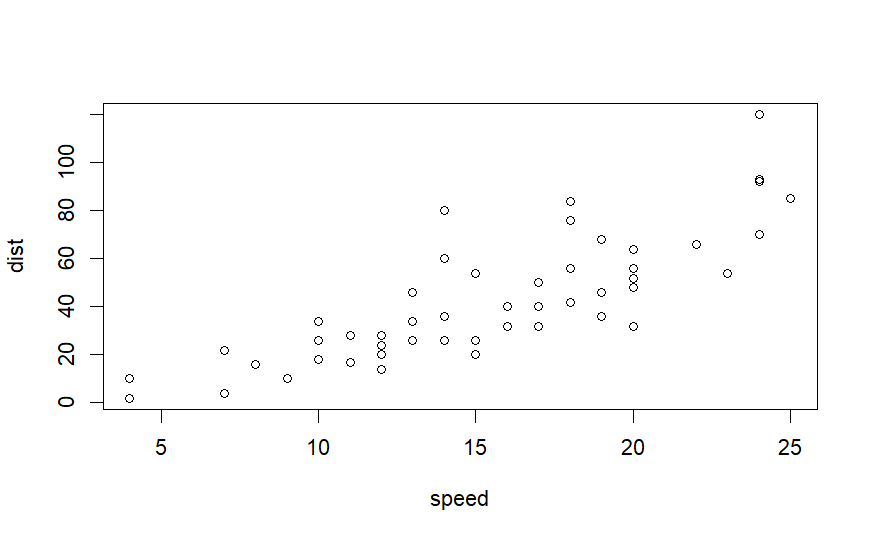

```r
plot(cars)
```

This is a bibliographic reference: Dumbaugh et al. (2022). I will add a bibliography at the end.

I will now test various functions from [Geocomputation in R](https://r.geocompx.org/) in the box below.

## Basic Map of the United States

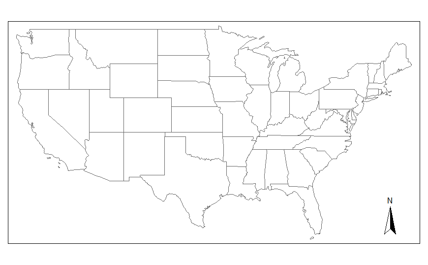

```r
library(sf)
library(terra)
library(spData)
library(spDataLarge)
library(tmap)

nz_elev = rast(system.file("raster/nz_elev.tif", package = "spDataLarge"))

(tm_shape(us_states)) +
  tm_borders() +
  tm_compass()
```

## Map of New Orleans

I will also create some examples of street maps following [Joshua McCrain’s street maps in R guide](https://joshuamccrain.com/tutorials/maps/streets_tutorial.html)

```r
library(tidyverse)
library(osmdata) # package for working with streets
library(showtext) # for custom fonts
library(ggmap)
library(rvest)
available_tags("highway")
```

| Key | Value |
| --- | --- |
| highway | bridleway |
| highway | bus_guideway |
| highway | bus_stop |
| highway | busway |
| highway | construction |
| highway | corridor |
| highway | crossing |
| highway | cycleway |
| highway | cyclist_waiting_aid |
| highway | elevator |

[output cut: 46 more lines]

```r
getbb("New Orleans Louisiana")
```

```
        min       max
x -90.13993 -89.62518
y  29.86548  30.19947
```

```r
big_streets <- getbb("New Orleans Louisiana")%>%
  opq()%>%
  add_osm_feature(key = "highway",
                  value = c("motorway", "primary", "motorway_link", "primary_link")) %>%
  osmdata_sf()

# Above, I tried to input "residential" as a category as well, but this resulted in a very blocky map that does not show the residential areas and street connections well. I will likely have to zoom in much closer to specific neighbourhoods in each city in order to make any observations. After this first test run, the residential category was removed from the previous line of code.

big_streets
```

```
Object of class 'osmdata' with:
                 $bbox : 29.8654809,-90.1399307,30.1994687,-89.6251763
        $overpass_call : The call submitted to the overpass API
                 $meta : metadata including timestamp and version numbers
           $osm_points : 'sf' Simple Features Collection with 11678 points
            $osm_lines : 'sf' Simple Features Collection with 1860 linestrings
         $osm_polygons : 'sf' Simple Features Collection with 0 polygons
       $osm_multilines : NULL
    $osm_multipolygons : NULL
```

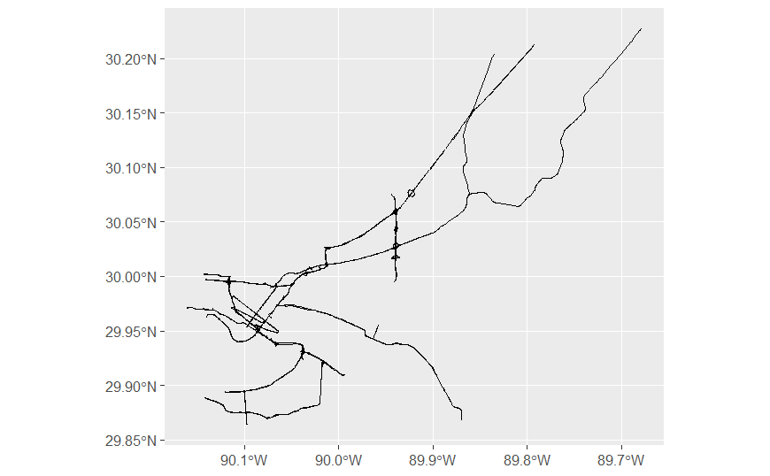

```r
View(big_streets[["osm_lines"]])

ggplot() +
  geom_sf(data = big_streets$osm_lines,
          inherit.aes = FALSE,
          color = "black")
```

```r
+labs(title=("New Orleans, Louisiana"), subtitle=("Major Road and Highway Map"))
```

```
Error in +labs(title = ("New Orleans, Louisiana"), subtitle = ("Major Road and Highway Map")) :
  invalid argument to unary operator
```

The first map generated has some basic major roads but needs improvements in how it is displayed and even which coordinates are used. The following map attempts to do this better.

```r
# Luckily, the same guide goes into how to zoom into the given map, add smaller streets, and other features.

library(tidyverse)
library(osmdata) # package for working with streets
library(showtext) # for custom fonts
library(ggmap)
library(rvest)
library(ggplot2) # I added this one myself in case it's necessary to run the code.
library(sf)
library(gapminder) # Might work for image saving?

available_tags("highway")
```

| Key | Value |
| --- | --- |
| highway | bridleway |
| highway | bus_guideway |
| highway | bus_stop |
| highway | busway |
| highway | construction |
| highway | corridor |
| highway | crossing |
| highway | cycleway |
| highway | cyclist_waiting_aid |
| highway | elevator |

[output cut: 46 more lines]

```r
getbb("New Orleans Louisiana")
```

```
        min       max
x -90.13993 -89.62518
y  29.86548  30.19947
```

```r
big_streets <- getbb("New Orleans Louisiana")%>%
  opq()%>%
  add_osm_feature(key = "highway",
                  value = c("motorway", "primary", "motorway_link", "primary_link")) %>%
  osmdata_sf()

med_streets <- getbb("New Orleans Louisiana")%>%
  opq()%>%
  add_osm_feature(key = "highway",
                  value = c("secondary", "tertiary", "secondary_link", "tertiary_link")) %>%
  osmdata_sf()


small_streets <- getbb("New Orleans Louisiana")%>%
  opq()%>%
  add_osm_feature(key = "highway",
                  value = c("residential", "living_street",
                            "unclassified",
                            "service", "footway"
                  )) %>%
  osmdata_sf()

big_streets
```

```
Object of class 'osmdata' with:
                 $bbox : 29.8654809,-90.1399307,30.1994687,-89.6251763
        $overpass_call : The call submitted to the overpass API
                 $meta : metadata including timestamp and version numbers
           $osm_points : 'sf' Simple Features Collection with 11678 points
            $osm_lines : 'sf' Simple Features Collection with 1860 linestrings
         $osm_polygons : 'sf' Simple Features Collection with 0 polygons
       $osm_multilines : NULL
    $osm_multipolygons : NULL
```

```r
View(big_streets[["osm_lines"]])

# Below this will be new experimental code that follows the guide in order to better map out New Orleans.

river <- getbb("New Orleans Louisiana")%>%
  opq()%>%
  add_osm_feature(key = "waterway", value = "river") %>%
  osmdata_sf()

bay <- getbb("New Orleans Louisiana")%>%
  opq()%>%
  add_osm_feature(key = "bay") %>%
  osmdata_sf()

railway <- getbb("New Orleans Louisiana")%>%
  opq()%>%
  add_osm_feature(key = "railway", value="rail") %>%
  osmdata_sf()

big_streets
```

```
Object of class 'osmdata' with:
                 $bbox : 29.8654809,-90.1399307,30.1994687,-89.6251763
        $overpass_call : The call submitted to the overpass API
                 $meta : metadata including timestamp and version numbers
           $osm_points : 'sf' Simple Features Collection with 11678 points
            $osm_lines : 'sf' Simple Features Collection with 1860 linestrings
         $osm_polygons : 'sf' Simple Features Collection with 0 polygons
       $osm_multilines : NULL
    $osm_multipolygons : NULL
```

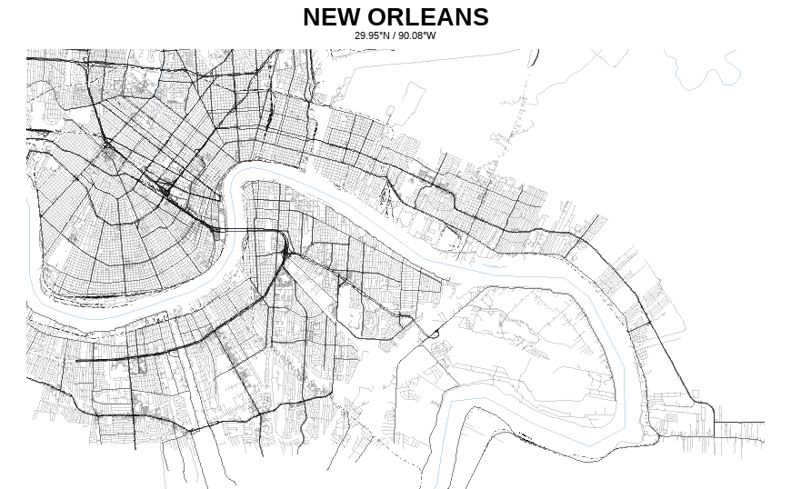

```r
View(big_streets[["osm_lines"]])

#The code below is copied with some modifications to test if it will run

font_add_google(name = "Lato", family = "lato") # add custom fonts
showtext_auto()

ggplot() +
  geom_sf(data = river$osm_lines,
          inherit.aes = FALSE,
          color = "steelblue",
          size = 1.0,
          alpha = .3) +
  geom_sf(data = bay$osm_lines,
          inherit.aes = FALSE,
          color = "steelblue",
          size = 1.0,
          alpha = 0.3) +
  geom_sf(data = railway$osm_lines,
          inherit.aes = FALSE,
          color = "black",
          size = .2,
          linetype="dotdash",
          alpha = .5) +
  geom_sf(data = med_streets$osm_lines,
          inherit.aes = FALSE,
          color = "black",
          size = .3,
          alpha = .5) +
  geom_sf(data = small_streets$osm_lines,
          inherit.aes = FALSE,
          color = "#666666",
          size = .2,
          alpha = .3) +
  geom_sf(data = big_streets$osm_lines,
          inherit.aes = FALSE,
          color = "black",
          size = .5,
          alpha = .6) +
  coord_sf(xlim = c(-90.14, -89.85),
           ylim = c(29.85, 30.00),
           expand = FALSE) +
  theme_void() + # get rid of background color, grid lines, etc.
  theme(plot.title = element_text(size = 20, family = "lato", face="bold", hjust=.5),
        plot.subtitle = element_text(family = "lato", size = 8, hjust=.5, margin=margin(2, 0, 5, 0))) +
  labs(title = "NEW ORLEANS", subtitle = "29.95°N / 90.08°W")
```

```r
#The coordinates were inputed from the ones generated for New Orleans earlier but modified to better show the parts of the city I wanted. The bay feature is one I added myself as well.

# Extra notes for later:
# - Inputting "New Orleans Louisiana" restricts it only to the one city, no other cities/areas in the metropolitan area are included on the map.
# BUT, trying to generate all of the data for Louisiana to then narrow down into that map takes ages to complete run and therefore, is not a practical option for this thesis which involves generating potentially dozens of metropolitan areas.
# Will look for an alternative solution that would work in these lines of codes and packages.For now, this test map looks at just New Orleans.
# Also could not get the bay to show up on the map. Not sure at this point in time why.
```

A better quality version of this map can be seen under the New Orleans pdf

## Map of College Street and Spadina Avenue (Toronto)

Here is an attempt to map an intersection I am more familiar with in terms of layout in order to see how accurate I can get the map to be. This map includes arterial roads, smaller streets, some public transit lines, and various building types; but is notably incomplete as mentioned afterwards.

```r
library(tidyverse)
library(osmdata) # package for working with streets
library(showtext) # for custom fonts
library(ggmap)
library(rvest)
library(ggplot2) # I added this one myself in case it's necessary to run the code.
library(sf)
library(gapminder) # Might work for image saving?

available_tags("highway") # https://wiki.openstreetmap.org/wiki/Map_features has different features you can add such as "landuse"
```

| Key | Value |
| --- | --- |
| highway | bridleway |
| highway | bus_guideway |
| highway | bus_stop |
| highway | busway |
| highway | construction |
| highway | corridor |
| highway | crossing |
| highway | cycleway |
| highway | cyclist_waiting_aid |
| highway | elevator |

[output cut: 46 more lines]

```r
available_tags("landuse")
```

| Key | Value |
| --- | --- |
| landuse | allotments |
| landuse | animal_keeping |
| landuse | aquaculture |
| landuse | basin |
| landuse | brownfield |
| landuse | cemetery |
| landuse | commercial |
| landuse | conservation |
| landuse | construction |
| landuse | depot |

[output cut: 32 more lines]

```r
# some that came up include: residential, reacreation_ground, industrial, institutional, education, commercial, conservation
available_tags("leisure")
```

| Key | Value |
| --- | --- |
| leisure | adult_gaming_centre |
| leisure | amusement_arcade |
| leisure | bandstand |
| leisure | beach_resort |
| leisure | bird_hide |
| leisure | common |
| leisure | dance |
| leisure | disc_golf_course |
| leisure | dog_park |
| leisure | escape_game |

[output cut: 23 more lines]

```r
# adult_gaming_centre, amusement_arcade, common, dance, dog_park, escape_game, fitness_centre, fitness_station, garden, hackerspace, miniature_golf, nature_reserve, park, picnic_table, pitch, playground, sports_centre, stadium, summer_camp, swimming_area, swimmin_pool, track, water_park, etc (some are less relevant to cities))
available_tags("building")
```

| Key | Value |
| --- | --- |
| building | allotment_house |
| building | annexe |
| building | apartments |
| building | bakehouse |
| building | barn |
| building | barracks |
| building | beach_hut |
| building | boathouse |
| building | bridge |
| building | bungalow |

[output cut: 91 more lines]

```r
# apartments, bungalow, bridge, church, commercial, college, dormitory, fire_station, garage, hospital, government, hotel, house, industiral, kindergarten, mosque, museum, office, parking, semidetached_house, retail, religious (instead of church or mosque? etc.), school, service, sports_centre, sports_hall, supermarket, toilets, university, train_station, etc.
available_tags("public_transport")
```

| Key | Value |
| --- | --- |
| public_transport | platform |
| public_transport | station |
| public_transport | stop_area |
| public_transport | stop_area_group |
| public_transport | stop_position |

```r
# platform, station, stop_area, stop_area_group, stop_position (?)
available_tags("railway")
```

| Key | Value |
| --- | --- |
| railway | abandoned |
| railway | buffer_stop |
| railway | construction |
| railway | crossing |
| railway | derail |
| railway | disused |
| railway | funicular |
| railway | halt |
| railway | level_crossing |
| railway | light_rail |

[output cut: 24 more lines]

```r
NA
NA
NA
```

```r
library(tidyverse)
library(osmdata) # package for working with streets
library(showtext) # for custom fonts
library(ggmap)
library(rvest)
library(ggplot2) # I added this one myself in case it's necessary to run the code.
library(sf)
library(gapminder) # Might work for image saving?l

getbb("Toronto Ontario")
```

```
        min       max
x -79.63928 -79.11322
y  43.57961  43.85544
```

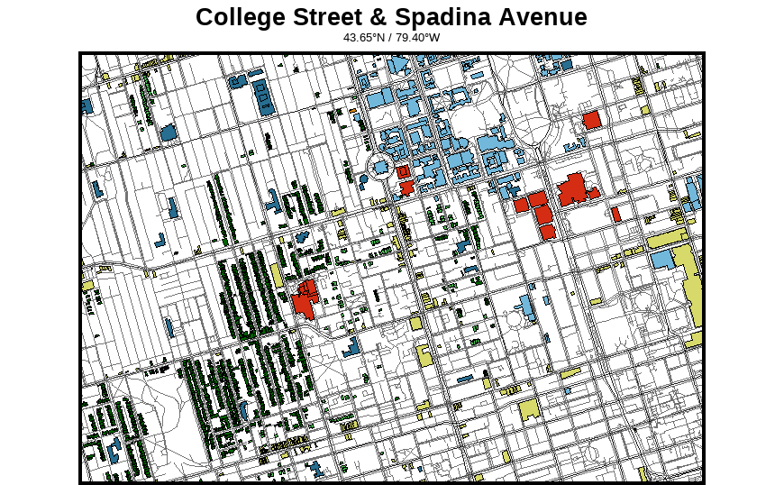

```r
big_streets <- getbb("Toronto Ontario")%>%
  opq()%>%
  add_osm_feature(key = "highway",
                  value = c("motorway", "primary", "motorway_link", "primary_link")) %>%
  osmdata_sf()

med_streets <- getbb("Toronto Ontario")%>%
  opq()%>%
  add_osm_feature(key = "highway",
                  value = c("secondary", "tertiary", "secondary_link", "tertiary_link")) %>%
  osmdata_sf()


small_streets <- getbb("Toronto Ontario")%>%
  opq()%>%
  add_osm_feature(key = "highway",
                  value = c("residential", "living_street",
                            "unclassified",
                            "service", "footway"
                  )) %>%
  osmdata_sf()

railway <- getbb("Toronto Ontario")%>%
  opq()%>%
  add_osm_feature(key = "railway",
                   value = ("rail")) %>%
  osmdata_sf()

detached <- getbb("Toronto Ontario")%>%
  opq()%>%
  add_osm_feature(key = "building",
                  value = "house") %>%
  osmdata_sf()

semidetached <- getbb("Toronto Ontario")%>%
  opq()%>%
  add_osm_feature(key = "building", value =  "semidetached_house") %>%
  osmdata_sf()

apartments <- getbb("Toronto Ontario")%>%
  opq()%>%
  add_osm_feature(key = "building", value = "apartment") %>%
  osmdata_sf()

collegeuniversity <- getbb("Toronto Ontario")%>%
  opq()%>%
  add_osm_feature(key = "building", value = c("college", "university", "dormitory")) %>%
  osmdata_sf()

schools <- getbb("Toronto Ontario")%>%
  opq()%>%
  add_osm_feature(key = "building", value = c("school", "kindergarten"))%>%
  osmdata_sf()

stores <- getbb("Toronto Ontario")%>%
  opq()%>%
  add_osm_feature(key = "building", value = "retail")%>%
  osmdata_sf()

supermarkets <- getbb("Toronto Ontario")%>%
  opq()%>%
  add_osm_feature(key = "building", value = "supermarket")%>%
  osmdata_sf()

industrial <- getbb("Toronto Ontario")%>%
  opq()%>%
  add_osm_feature(key = "building", value = "industrial")%>%
  osmdata_sf()

sports <- getbb("Toronto Ontario")%>%
  opq()%>%
  add_osm_feature(key = "building", value = c("sports_centre", "sports_hall"))%>%
  osmdata_sf()

healthcare <- getbb("Toronto Ontario")%>%
  opq()%>%
  add_osm_feature(key = "building", value = "hospital")%>%
  osmdata_sf()

religious <- getbb("Toronto Ontario")%>%
  opq()%>%
  add_osm_feature(key = "building", value = "religious")%>%
  osmdata_sf()

train_station <- getbb("Toronto Ontario")%>%
  opq()%>%
  add_osm_feature(key = "building", value = "train_station")%>%
  osmdata_sf()

subway_entrance <- getbb("Toronto Ontario")%>%
  opq()%>%
  add_osm_feature(key = "building", value = "subway_entrance")%>%
  osmdata_sf()

subwayline <- getbb("Toronto Ontario")%>%
  opq()%>%
  add_osm_feature(key = "building", value = "subway")%>%
  osmdata_sf()

lrttrams <- getbb("Toronto Ontario")%>%
  opq()%>%
  add_osm_feature(key = "railway",
                   value = c("light_rail", "tram")) %>%
  osmdata_sf()

tram_stops <- getbb("Toronto Ontario")%>%
  opq()%>%
  add_osm_feature(key = "railway", value = "tram_stop") %>%
  osmdata_sf()

font_add_google(name = "Lato", family = "lato") # add custom fonts
showtext_auto()

ggplot() +
  geom_sf(data = railway$osm_lines,
          inherit.aes = FALSE,
          color = "black",
          size = .1,
          linetype= "21",
          alpha = .6) +
  geom_sf(data = med_streets$osm_lines,
          inherit.aes = FALSE,
          color = "black",
          size = .3,
          alpha = .9) +
  geom_sf(data = small_streets$osm_lines,
          inherit.aes = FALSE,
          color = "#666666",
          size = .2,
          alpha = .9) +
  geom_sf(data = big_streets$osm_lines,
          inherit.aes = FALSE,
          color = "black",
          size = .5,
          alpha = .9) +
  geom_sf(data = detached$osm_polygons,
          inherit.aes = FALSE,
          color = "black",
          fill = "darkgreen",
          size = 0.5,
          alpha = 1) +
  geom_sf(data = semidetached$osm_polygons,
          inherit.aes = FALSE,
          color = "black",
          fill = "#4bbf54",
          size = 0.5,
          alpha = 1) +
    geom_sf(data = apartments$osm_polygons,
          inherit.aes = FALSE,
          color = "black",
          fill = "#a1eda7",
          size = 0.5,
          alpha = 1) +
  geom_sf(data = collegeuniversity$osm_polygons,
          inherit.aes = FALSE,
          color = "black",
          fill = "#72b8db",
          size = 0.5,
          alpha = 1) +
  geom_sf(data = schools$osm_polygons,
          inherit.aes = FALSE,
          color = "black",
          fill = "#276e91",
          size = 0.5,
          alpha = 1) +
  geom_sf(data = stores$osm_polygons,
          inherit.aes = FALSE,
          color = "black",
          fill = "#d7d96a",
          size = 0.5,
          alpha = 1) +
  geom_sf(data = supermarkets$osm_polygons,
          inherit.aes = FALSE,
          color = "black",
          fill = "#fbff19",
          size = 0.5,
          alpha = 1) +
  geom_sf(data = industrial$osm_polygons,
          inherit.aes = FALSE,
          color = "black",
          fill = "#572a17",
          size = 0.5,
          alpha = 1) +
  geom_sf(data = sports$osm_polygons,
          inherit.aes = FALSE,
          color = "black",
          fill = "#d48713",
          size = 0.5,
          alpha = 1) +
  geom_sf(data = healthcare$osm_polygons,
          inherit.aes = FALSE,
          color = "black",
          fill = "#d42d13",
          size = 0.5,
          alpha = 1) +
  geom_sf(data = religious$osm_polygons,
          inherit.aes = FALSE,
          color = "black",
          fill = "#6a5d99",
          size = 0.5,
          alpha = 1) +
  geom_sf(data = tram_stops$osm_polygons,
          inherit.aes = FALSE,
          color = "black",
          fill = "#5c5c5c",
          size = 0.5,
          alpha = 1) +
  geom_sf(data = lrttrams$osm_lines,
          inherit.aes = FALSE,
          color = "#5c5c5c",
          size = .1,
          linetype= "21",
          alpha = .6) +
  geom_sf(data = subway_entrance$osm_polygons,
          inherit.aes = FALSE,
          color = "black",
          fill = "#292536",
          size = 0.5,
          alpha = 1) +
  geom_sf(data = subwayline$osm_lines,
          inherit.aes = FALSE,
          color = "#292536",
          size = .1,
          linetype= "21",
          alpha = .6) +
  coord_sf(xlim = c(-79.42, -79.38),
           ylim = c(43.645, 43.665),
           expand = FALSE) +
  theme_void() + # get rid of background color, grid lines, etc.
  theme(plot.title = element_text(size = 20, family = "lato", face="bold", hjust=.5),
        panel.border = element_rect(color = "black", fill = NA, size = 2),
        plot.subtitle = element_text(family = "lato", size = 10, hjust=.5, margin=margin(2, 0, 5, 0))) +
  labs(title = "College Street & Spadina Avenue", subtitle = "43.65°N / 79.40°W")
```

```r
# ggsave("collegeandspadina.pdf", dpi = 400, width = 7, height = 5, units = "in")
```

I was able to include a variety of building types in the previous neighbourhood map. The legend is as follows: - Dark green: detached housing - Green: semi-detached housing - Light green: apartment buildings - Light blue: institutional/university/college buildings - Blue: schools and daycares - Yellow: retail areas - Bright yellow: supermarkets (do not appear on this map) - Purple: religious buildings (do not appear on this map) - Red: hospitals (there was no option to include other medical facilities) - Brown: industrial buildings - Streetcar lines and subway lines

However, a few evident issues arise. 1. A lot of housing buildings do not appear. OpenStreetMap recognizes many of them as buildings in residential zones, but not as residential buildings. I will have to check if this is as common of a problem in American cities as well though. 2. Some building types do not have their own categories (medical facilities, grocery stores, etc.) from what I can tell at this point in time. 3. Some buildings have several uses (e.g. mixed residential and retail) that I do not believe can be represented as such. 4. The image is very pixelated unless you open it as a .pdf file where the details are rendered in greater quality. The College and Spadina PDF shows this detail.

## Map of Oak Park, Chicago

This map will test if buildings are better classified as residential buildings in a major US city (that is also part of one of the metropolitan areas that will likely be used in this study).

```r
# most of this code is copied from the previous map but modified to be used for a different neighbourhood

library(tidyverse)
library(osmdata)
library(showtext)
library(ggmap)
library(rvest)
library(ggplot2)
library(sf)
library(gapminder)

getbb("Chicago Illinois")
```

```
        min       max
x -87.94009 -87.52408
y  41.64453  42.02304
```

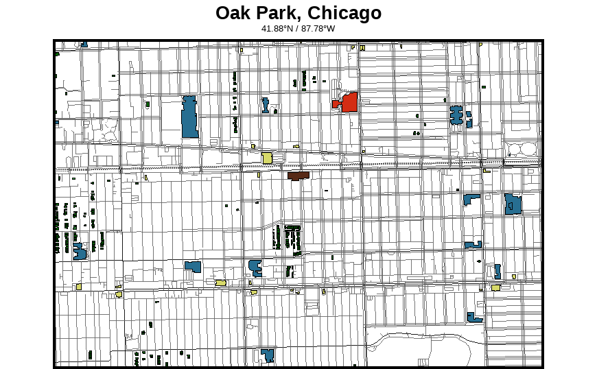

```r
big_streets <- getbb("Chicago Illinois")%>%
  opq()%>%
  add_osm_feature(key = "highway",
                  value = c("motorway", "primary", "motorway_link", "primary_link")) %>%
  osmdata_sf()

med_streets <- getbb("Chicago Illinois")%>%
  opq()%>%
  add_osm_feature(key = "highway",
                  value = c("secondary", "tertiary", "secondary_link", "tertiary_link")) %>%
  osmdata_sf()

small_streets <- getbb("Chicago Illinois")%>%
  opq()%>%
  add_osm_feature(key = "highway",
                  value = c("residential", "living_street",
                            "unclassified",
                            "service", "footway")) %>%
  osmdata_sf()

railway <- getbb("Chicago Illinois")%>%
  opq()%>%
  add_osm_feature(key = "railway",
                   value = ("rail")) %>%
  osmdata_sf()

detached <- getbb("Chicago Illinois")%>%
  opq()%>%
  add_osm_feature(key = "building",
                  value = "house") %>%
  osmdata_sf()

semidetached <- getbb("Chicago Illinois")%>%
  opq()%>%
  add_osm_feature(key = "building", value =  "semidetached_house") %>%
  osmdata_sf()

apartments <- getbb("Chicago Illinois")%>%
  opq()%>%
  add_osm_feature(key = "building", value = "apartment") %>%
  osmdata_sf()

collegeuniversity <- getbb("Chicago Illinois")%>%
  opq()%>%
  add_osm_feature(key = "building", value = c("college", "university", "dormitory")) %>%
  osmdata_sf()

schools <- getbb("Chicago Illinois")%>%
  opq()%>%
  add_osm_feature(key = "building", value = c("school", "kindergarten"))%>%
  osmdata_sf()

stores <- getbb("Chicago Illinois")%>%
  opq()%>%
  add_osm_feature(key = "building", value = "retail")%>%
  osmdata_sf()

supermarkets <- getbb("Chicago Illinois")%>%
  opq()%>%
  add_osm_feature(key = "building", value = "supermarket")%>%
  osmdata_sf()

industrial <- getbb("Chicago Illinois")%>%
  opq()%>%
  add_osm_feature(key = "building", value = "industrial")%>%
  osmdata_sf()

sports <- getbb("Chicago Illinois")%>%
  opq()%>%
  add_osm_feature(key = "building", value = c("sports_centre", "sports_hall"))%>%
  osmdata_sf()

healthcare <- getbb("Chicago Illinois")%>%
  opq()%>%
  add_osm_feature(key = "building", value = "hospital")%>%
  osmdata_sf()

religious <- getbb("Chicago Illinois")%>%
  opq()%>%
  add_osm_feature(key = "building", value = "religious")%>%
  osmdata_sf()

train_station <- getbb("Chicago Illinois")%>%
  opq()%>%
  add_osm_feature(key = "building", value = "train_station")%>%
  osmdata_sf()

subway_entrance <- getbb("Chicago Illinois")%>%
  opq()%>%
  add_osm_feature(key = "building", value = "subway_entrance")%>%
  osmdata_sf()

subwayline <- getbb("Chicago Illinois")%>%
  opq()%>%
  add_osm_feature(key = "building", value = "subway")%>%
  osmdata_sf()

lrttrams <- getbb("Chicago Illinois")%>%
  opq()%>%
  add_osm_feature(key = "railway",
                   value = c("light_rail", "tram")) %>%
  osmdata_sf()

tram_stops <- getbb("Chicago Illinois")%>%
  opq()%>%
  add_osm_feature(key = "railway", value = "tram_stop") %>%
  osmdata_sf()

font_add_google(name = "Lato", family = "lato") # add custom fonts
showtext_auto()

ggplot() +
  geom_sf(data = railway$osm_lines,
          inherit.aes = FALSE,
          color = "black",
          size = .1,
          linetype= "21",
          alpha = .6) +
  geom_sf(data = med_streets$osm_lines,
          inherit.aes = FALSE,
          color = "black",
          size = .3,
          alpha = .9) +
  geom_sf(data = small_streets$osm_lines,
          inherit.aes = FALSE,
          color = "#666666",
          size = .2,
          alpha = .9) +
  geom_sf(data = big_streets$osm_lines,
          inherit.aes = FALSE,
          color = "black",
          size = .5,
          alpha = .9) +
  geom_sf(data = detached$osm_polygons,
          inherit.aes = FALSE,
          color = "black",
          fill = "darkgreen",
          size = 0.5,
          alpha = 1) +
  geom_sf(data = semidetached$osm_polygons,
          inherit.aes = FALSE,
          color = "black",
          fill = "#4bbf54",
          size = 0.5,
          alpha = 1) +
    geom_sf(data = apartments$osm_polygons,
          inherit.aes = FALSE,
          color = "black",
          fill = "#a1eda7",
          size = 0.5,
          alpha = 1) +
  geom_sf(data = collegeuniversity$osm_polygons,
          inherit.aes = FALSE,
          color = "black",
          fill = "#72b8db",
          size = 0.5,
          alpha = 1) +
  geom_sf(data = schools$osm_polygons,
          inherit.aes = FALSE,
          color = "black",
          fill = "#276e91",
          size = 0.5,
          alpha = 1) +
  geom_sf(data = stores$osm_polygons,
          inherit.aes = FALSE,
          color = "black",
          fill = "#d7d96a",
          size = 0.5,
          alpha = 1) +
  geom_sf(data = supermarkets$osm_polygons,
          inherit.aes = FALSE,
          color = "black",
          fill = "#fbff19",
          size = 0.5,
          alpha = 1) +
  geom_sf(data = industrial$osm_polygons,
          inherit.aes = FALSE,
          color = "black",
          fill = "#572a17",
          size = 0.5,
          alpha = 1) +
  geom_sf(data = sports$osm_polygons,
          inherit.aes = FALSE,
          color = "black",
          fill = "#d48713",
          size = 0.5,
          alpha = 1) +
  geom_sf(data = healthcare$osm_polygons,
          inherit.aes = FALSE,
          color = "black",
          fill = "#d42d13",
          size = 0.5,
          alpha = 1) +
  geom_sf(data = religious$osm_polygons,
          inherit.aes = FALSE,
          color = "black",
          fill = "#6a5d99",
          size = 0.5,
          alpha = 1) +
  geom_sf(data = tram_stops$osm_polygons,
          inherit.aes = FALSE,
          color = "black",
          fill = "#5c5c5c",
          size = 0.5,
          alpha = 1) +
  geom_sf(data = lrttrams$osm_lines,
          inherit.aes = FALSE,
          color = "#5c5c5c",
          size = .1,
          linetype= "21",
          alpha = .6) +
  geom_sf(data = subway_entrance$osm_polygons,
          inherit.aes = FALSE,
          color = "black",
          fill = "#292536",
          size = 0.5,
          alpha = 1) +
  geom_sf(data = subwayline$osm_lines,
          inherit.aes = FALSE,
          color = "#292536",
          size = .1,
          linetype= "21",
          alpha = .6) +
  coord_sf(xlim = c(-87.80, -87.76),
           ylim = c(41.875, 41.895),
           expand = FALSE) +
  theme_void() + # get rid of background color, grid lines, etc.
  theme(plot.title = element_text(size = 20, family = "lato", face="bold", hjust=.5),
        panel.border = element_rect(color = "black", fill = NA, size = 2),
        plot.subtitle = element_text(family = "lato", size = 10, hjust=.5, margin=margin(2, 0, 5, 0))) +
  labs(title = "Oak Park, Chicago", subtitle = "41.88°N / 87.78°W")
```

```r
# ggsave("oakparkchicago.pdf", dpi = 400, width = 7, height = 5, units = "in")
```

The Oak Park map contains even fewer labelled buildings than the College and Spadina map. An alternative solution to this problem will be to focus on mapping different zones rather than building types specifically. Here is another attempt at recreating this neighbourhood’s map but with zone labels instead:

```r
library(osmdata)
library(showtext)
library(ggmap)
library(rvest)
library(ggplot2)
library(sf)
library(gapminder)

getbb("Chicago Illinois")
```

```
        min       max
x -87.94009 -87.52408
y  41.64453  42.02304
```

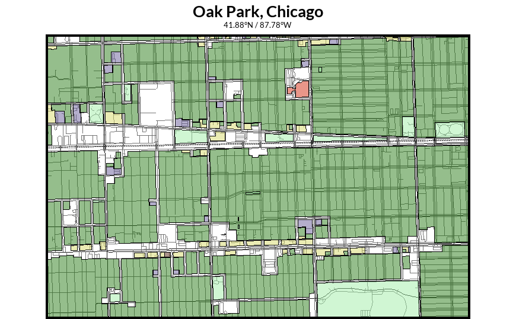

```r
big_streets <- getbb("Chicago Illinois")%>%
  opq()%>%
  add_osm_feature(key = "highway",
                  value = c("motorway", "primary", "motorway_link", "primary_link")) %>%
  osmdata_sf()

med_streets <- getbb("Chicago Illinois")%>%
  opq()%>%
  add_osm_feature(key = "highway",
                  value = c("secondary", "tertiary", "secondary_link", "tertiary_link")) %>%
  osmdata_sf()

small_streets <- getbb("Chicago Illinois")%>%
  opq()%>%
  add_osm_feature(key = "highway",
                  value = c("residential", "living_street",
                            "unclassified",
                            "service", "footway")) %>%
  osmdata_sf()

railway <- getbb("Chicago Illinois")%>%
  opq()%>%
  add_osm_feature(key = "railway", value = ("rail")) %>%
  osmdata_sf()

residentialzones <- getbb("Chicago Illinois")%>%
  opq()%>%
  add_osm_feature(key = "landuse", value = "residential") %>%
  osmdata_sf()

institutionalzones <- getbb("Chicago Illinois")%>%
  opq()%>%
  add_osm_feature(key = "landuse", value = "institutional") %>%
  osmdata_sf()

schoolzones <- getbb("Chicago Illinois")%>%
  opq()%>%
  add_osm_feature(key = "landuse", value = "education")%>%
  osmdata_sf()

commercialzones <- getbb("Chicago Illinois")%>%
  opq()%>%
  add_osm_feature(key = "landuse", value = "commercial")%>%
  osmdata_sf()

industrialzones <- getbb("Chicago Illinois")%>%
  opq()%>%
  add_osm_feature(key = "landuse", value = "industrial")%>%
  osmdata_sf()

recreationalzones <- getbb("Chicago Illinois")%>%
  opq()%>%
  add_osm_feature(key = "landuse", value = "reacreation_ground")%>%
  osmdata_sf()

healthcare <- getbb("Chicago Illinois")%>%
  opq()%>%
  add_osm_feature(key = "building", value = "hospital")%>%
  osmdata_sf()
# there was no landuse option for healthcare, so I kept the hospital buildings but this still likely does not include medical clinics

parks <- getbb("Chicago Illinois")%>%
  opq()%>%
  add_osm_feature(key = "leisure", value = c("park", "garden")) %>%
  osmdata_sf()

religiouszones <- getbb("Chicago Illinois")%>%
  opq()%>%
  add_osm_feature(key = "landuse", value = "religious")%>%
  osmdata_sf()

train_station <- getbb("Chicago Illinois")%>%
  opq()%>%
  add_osm_feature(key = "building", value = "train_station")%>%
  osmdata_sf()

subway_entrance <- getbb("Chicago Illinois")%>%
  opq()%>%
  add_osm_feature(key = "building", value = "subway_entrance")%>%
  osmdata_sf()

subwayline <- getbb("Chicago Illinois")%>%
  opq()%>%
  add_osm_feature(key = "building", value = "subway")%>%
  osmdata_sf()

lrttrams <- getbb("Chicago Illinois")%>%
  opq()%>%
  add_osm_feature(key = "railway",
                   value = c("light_rail", "tram")) %>%
  osmdata_sf()

tram_stops <- getbb("Chicago Illinois")%>%
  opq()%>%
  add_osm_feature(key = "railway", value = "tram_stop") %>%
  osmdata_sf()

font_add_google(name = "Lato", family = "lato") # add custom fonts
showtext_auto()

ggplot() +
  geom_sf(data = railway$osm_lines,
          inherit.aes = FALSE,
          color = "black",
          size = .1,
          linetype= "21",
          alpha = .6) +
  geom_sf(data = med_streets$osm_lines,
          inherit.aes = FALSE,
          color = "black",
          size = .3,
          alpha = .9) +
  geom_sf(data = small_streets$osm_lines,
          inherit.aes = FALSE,
          color = "#666666",
          size = .2,
          alpha = .9) +
  geom_sf(data = big_streets$osm_lines,
          inherit.aes = FALSE,
          color = "black",
          size = .5,
          alpha = .9) +
  geom_sf(data = residentialzones$osm_polygons,
          inherit.aes = FALSE,
          color = "black",
          fill = "#2b7d19",
          size = 0.5,
          alpha = 0.5) +
  geom_sf(data = parks$osm_polygons,
          inherit.aes = FALSE,
          color = "black",
          fill = "#a1eda7",
          size = 0.5,
          alpha = 0.5) +
  geom_sf(data = institutionalzones$osm_polygons,
          inherit.aes = FALSE,
          color = "black",
          fill = "#72b8db",
          size = 0.5,
          alpha = 0.5) +
  geom_sf(data = schoolzones$osm_polygons,
          inherit.aes = FALSE,
          color = "black",
          fill = "#276e91",
          size = 0.5,
          alpha = 0.5) +
  geom_sf(data = commercialzones$osm_polygons,
          inherit.aes = FALSE,
          color = "black",
          fill = "#d7d96a",
          size = 0.5,
          alpha = 0.5) +
  geom_sf(data = industrialzones$osm_polygons,
          inherit.aes = FALSE,
          color = "black",
          fill = "#572a17",
          size = 0.5,
          alpha = 0.5) +
  geom_sf(data = recreationalzones$osm_polygons,
          inherit.aes = FALSE,
          color = "black",
          fill = "#d48713",
          size = 0.5,
          alpha = 0.5) +
  geom_sf(data = healthcare$osm_polygons,
          inherit.aes = FALSE,
          color = "black",
          fill = "#d42d13",
          size = 0.5,
          alpha = 0.5) +
  geom_sf(data = religiouszones$osm_polygons,
          inherit.aes = FALSE,
          color = "black",
          fill = "#6a5d99",
          size = 0.5,
          alpha = 0.5) +
  geom_sf(data = tram_stops$osm_polygons,
          inherit.aes = FALSE,
          color = "black",
          fill = "#5c5c5c",
          size = 0.5,
          alpha = 1) +
  geom_sf(data = lrttrams$osm_lines,
          inherit.aes = FALSE,
          color = "#5c5c5c",
          size = .1,
          linetype= "21",
          alpha = .6) +
  geom_sf(data = subway_entrance$osm_polygons,
          inherit.aes = FALSE,
          color = "black",
          fill = "#292536",
          size = 0.5,
          alpha = 1) +
  geom_sf(data = subwayline$osm_lines,
          inherit.aes = FALSE,
          color = "#292536",
          size = .1,
          linetype= "21",
          alpha = .6) +
  coord_sf(xlim = c(-87.80, -87.76),
           ylim = c(41.875, 41.895),
           expand = FALSE) +
  theme_void() + # get rid of background color, grid lines, etc.
  theme(plot.title = element_text(size = 20, family = "lato", face="bold", hjust=.5),
        # legend = (legend.position = ("topright") + legend = c("Residential Zones", "Parks", "Schools", "Institutions", "Retail Zones", "Recreational Zones", "Hospitals", "Religious Buildings") + col = c("#2b7d19", "#a1eda7", "#276e91", "#72b8db", "#d7d96a", "#d48713", "#d42d13", "#6a5d99")),
        # tried to add the legend in but it would not work, not sure why
        panel.border = element_rect(color = "black", fill = NA, size = 2),
        plot.subtitle = element_text(family = "lato", size = 10, hjust=.5, margin=margin(2, 0, 5, 0))) +
  labs(title = "Oak Park, Chicago", subtitle = "41.88°N / 87.78°W")
ggsave("oakparkchicagozones2.pdf", dpi = 400, width = 7, height = 5, units = "in")
```

Although the Oak Park, Chicago map with zones better outlines zone uses (including residential zones, parks, etc.), there are still some spots (especially in retail spaces) that are not shown on the map.

## References

Dumbaugh, Eric, Yanmei Li, Dibakar Saha, and Wesley Marshall. 2022. “Why Do Lower-Income Areas Experience Worse Road Safety Outcomes? Examining the Role of the Built Environment in Orange County, Florida.” *TRANSPORTATION RESEARCH INTERDISCIPLINARY PERSPECTIVES* 16 (December): 100696. https://doi.org/10.1016/j.trip.2022.100696.